# R Notebook

1 MVP Now we’ll go back to CI creation in the normal fashion. We’ll take the ames data from the CIs lab earlier today and regard it now as a sample, we won’t be drawing any smaller samples from within it. This is the usual situation in an analysis: you use all the data available to you!

Task 1. Load the data again, clean_names(), and re-familiarise yourself with it

```r
ames <- read_csv("data/ames.csv") %>% clean_names()
```

Task 2. Investigate the distribution of lot_area. Is the distribution roughly normal? If not, what problems do you find?

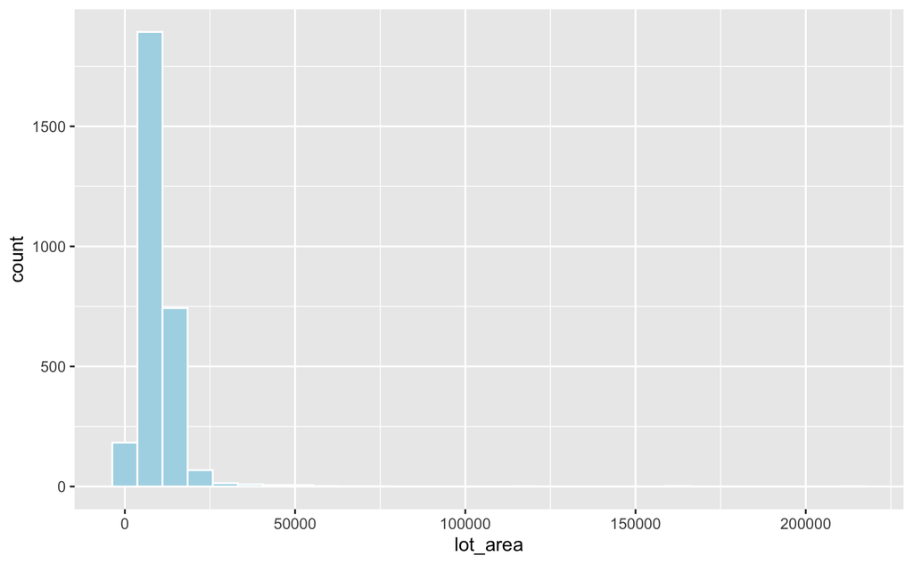

Task 3. Compute and visualise a bootstrap sampling distribution for the mean(lot_area) of the sold houses.

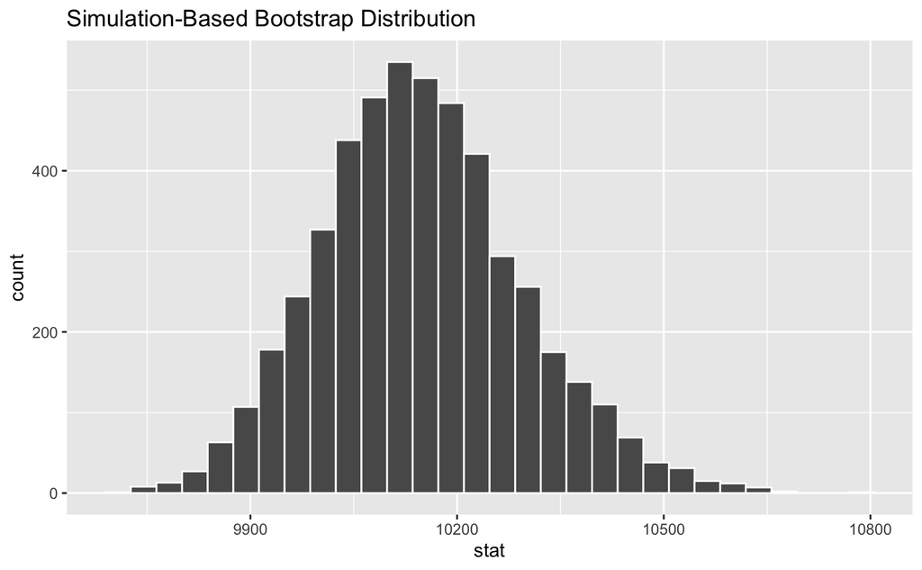

```r
resample_lot_area <- ames %>%
  specify(response = lot_area) %>%
  generate(reps = 5000, type = "bootstrap") %>%
  calculate(stat = "mean")
resample_lot_area %>%
  visualise(bins = 30)
```

Task 4. Use your bootstrap distribution to calculate a 95% CI for mean(lot_area), and visualise it on the distribution

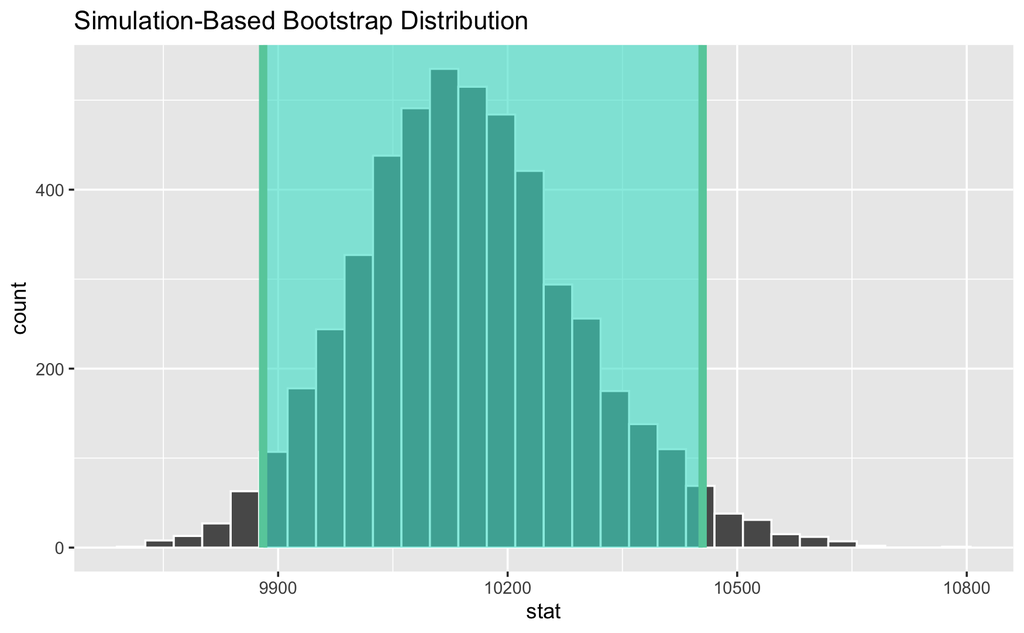

```r
infer_ci_95 <- resample_lot_area %>%
  get_ci(level = 0.95, type = "percentile")
# lower ci 9880.404
#upper_ci 10454.81

resample_lot_area %>%
  visualise(bins = 30) +
  shade_ci(endpoints = infer_ci_95)
```

Task 5. You would like to know the mean(lot_area) of the sold houses with higher confidence. Calculate the 99% CI for this variable (you can re-use your bootstrap distribution from above). Is it narrower or broader than the 95% CI? Does that make sense?

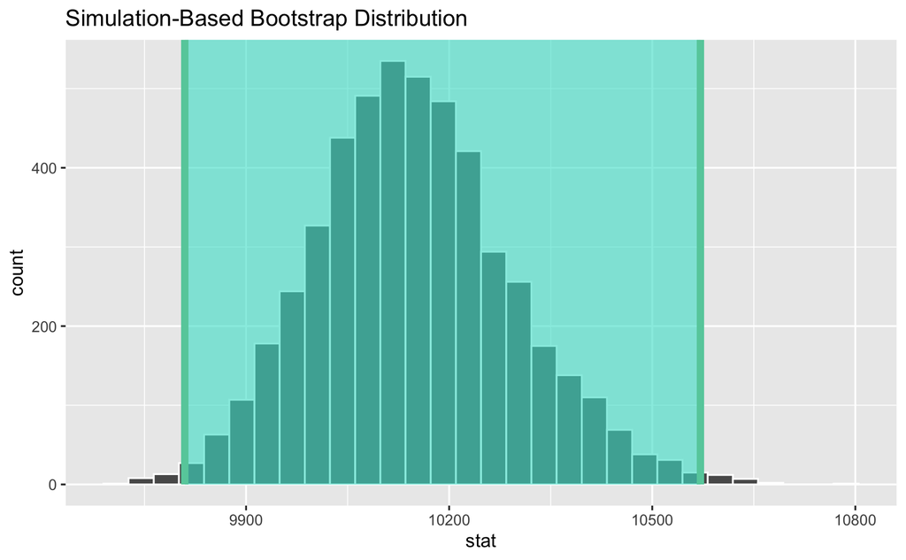

```r
infer_ci_99 <- resample_lot_area %>%
  get_ci(level = 0.99, type = "percentile")
# lower ci 9809.478
#upper_ci 10571.19
#it's a wider range and makes perfect sense
resample_lot_area %>%
  visualise(bins = 30) +
  shade_ci(endpoints = infer_ci_99)
```

Task 6. Calculate the point estimate of the mean(lot_area)

```r
mean_lot_area <- resample_lot_area %>%
  ungroup() %>%
  summarise(mean_lot_area = mean(stat))

mean_lot_area
```

| mean_lot_area |
| --- |
| 10148.43 |